# Practical ML Project

Anthony Cazares

2023-04-29

```r
library(AppliedPredictiveModeling)
library(caret)
library(lubridate)
library(pgmm)
library(rpart)
library(gbm)
library(forecast)
library(xgboost)
library(Amelia)
library(randomForest)
library(tidyverse)
```

# Load Data

```r
testing <- read.csv("~\\GitHub\\JohnsHopkinsCourse\\datasciencecoursera\\PracticalML\\Project\\pml-testing.csv")

training <- read.csv("~\\GitHub\\JohnsHopkinsCourse\\datasciencecoursera\\PracticalML\\Project\\pml-training.csv")
```

# Create Data Partitions

```r
inTrain <- createDataPartition(training$classe,times = 1, p = 0.8, list = FALSE)
training <- training[inTrain,]
testtrain <- training[-inTrain,]
```

# Fix Data

The “classe” value is a factor variable.

```r
training$classe <- as.factor(training$classe)
testtrain$classe <- as.factor(testtrain$classe)
```

Find variables without missing values to not have NA problems in fitting models.

```r
fullvars <- c()
for (col in colnames(training)) {
  if(sum(!is.na(training[,col]))/15699>0.9){
    fullvars <- c(fullvars, col)
  }
}
```

Create Data with the columns that dont have missing values

```r
fulltr <- training[,fullvars]
```

Confirming there is nothing missing.

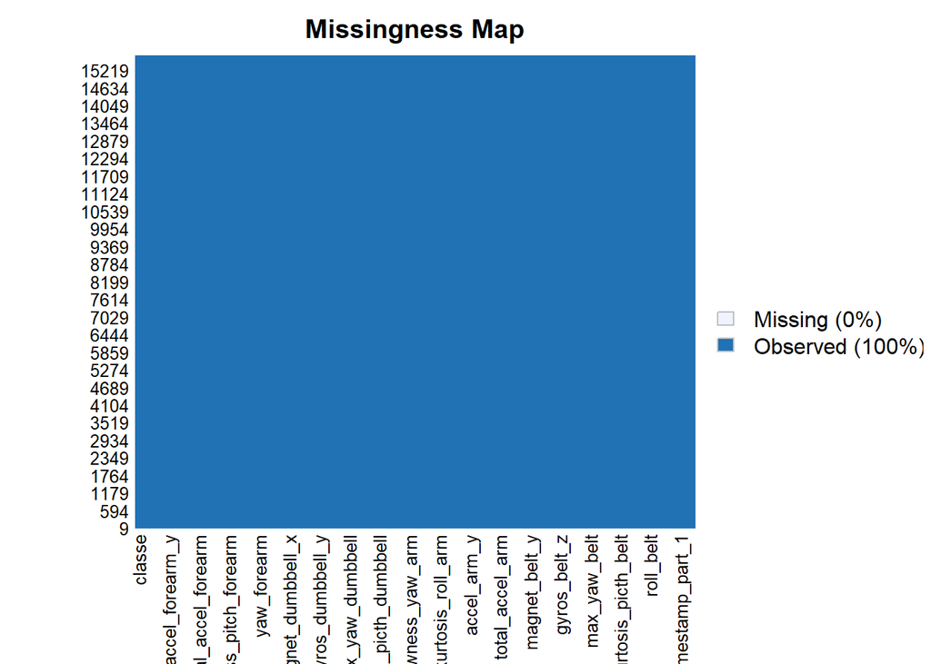

```r
missmap(fulltr)
```

There are too many variables. Will try to weed out the nonimportant variables by fitting a default random forest then using Variable importance function.

Default Random Forest

```r
rf1 <- randomForest(classe~.,
                    data = fulltr,
                    treesize=1000)
```

Saving the Important Variables

```r
impVars <- varImp(rf1) %>% arrange(-Overall) %>%
  filter(Overall >800) %>% row.names()
```

Checking the missingness of the important variables

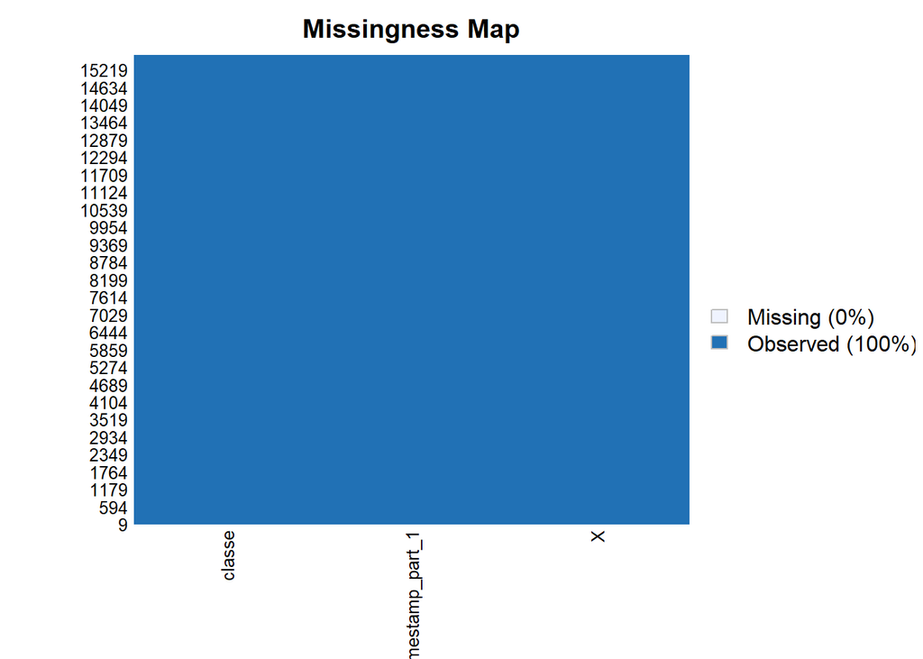

```r
imptraining <- training %>% select(impVars, classe)
missmap(imptraining)
```